# Chapter 3

# 1. Exercises

# 2. Analysis of Reading dataset - Estimation

In this set of slides, we will replicate the elements of the analysis conducted on the `reading` data presented in the lecture slides. Our first step is to load the data which is available in the `idar` R package. Assuming that this package is installed (if not, please refer to Section 1 of Chapter 1), we can load the data as follows:

```r
library(idar)
data(reading)
```

We can have a first look at the data using the function `head` as follows:

```r
head(reading)
```

```
##   id    score       age   group
## 1  1 59.98881 10.937378 Control
## 2  2 60.39487 10.261197 Control
## 3  3 70.02395 11.795009 Control
## 4  4 41.47707  6.471665 Control
## 5  5 29.15497  6.321822 Control
## 6  6 58.84009  9.449869 Control
```

```
  id    score       age   group
1  1 59.98881 10.937378 Control
2  2 60.39487 10.261197 Control
3  3 70.02395 11.795009 Control
4  4 41.47707  6.471665 Control
5  5 29.15497  6.321822 Control
6  6 58.84009  9.449869 Control
```

To compare the two groups (i.e. `Control` and `Treatment`), we can start by comparing the empirical distributions using boxplots similarly to the graph presented in slide 2. For this purpose, we will construct two new variables, called `control` and `treatment`, which correspond to the scores in these groups. This can be done as follows:

```r
control = reading$score[reading$group == "Control"]
treatment = reading$score[reading$group == "Treatment"]
```

The notation `reading$score[reading$group == "Control"]` means that in the dataset called `reading`, consider the variable called `score` but only select the values where the variable `group` is equal to `Control`. Using these variables we can easily consider boxplots as follows:

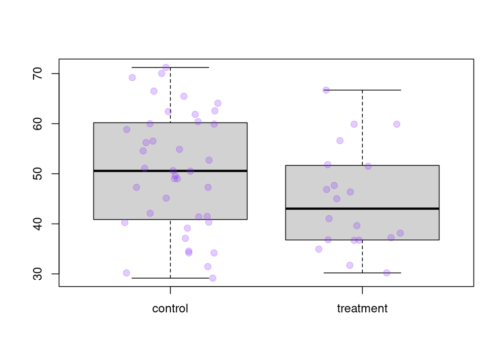

```r
boxplot_w_points(control, treatment)
```

As suggested in slide 9, a possible model is given by:

$$\color{#e64173}{\text{Score}_i} = \beta_0 + \beta_1 \color{#6A5ACD}{\text{Group}_i} + \beta_2 \color{#20B2AA}{\text{Age}_i} + \epsilon_i, \quad \epsilon_i \overset{iid}{\sim} \mathcal{N}(0, \sigma^2).$$
We will refer to this model as “Model 1”. The parameters of this first model can be estimated using the function `lm` as follows:

```r
mod1 = lm(score ~ group + age, data = reading)
summary(mod1)
```

```
##
## Call:
## lm(formula = score ~ group + age, data = reading)
##
## Residuals:
##    Min     1Q Median     3Q    Max
## -9.247 -3.532  0.423  3.180 12.569
##
## Coefficients:
##                Estimate Std. Error t value Pr(>|t|)
## (Intercept)     -7.8639     3.3238  -2.366   0.0214 *
## groupTreatment   6.3771     1.3931   4.578  2.6e-05 ***
## age              6.6457     0.3695  17.985  < 2e-16 ***
## ---
## Signif. codes:  0 '***' 0.001 '**' 0.01 '*' 0.05 '.' 0.1 ' ' 1
##
## Residual standard error: 4.447 on 57 degrees of freedom
## Multiple R-squared:  0.8586, Adjusted R-squared:  0.8536
## F-statistic:   173 on 2 and 57 DF,  p-value: < 2.2e-16
```

```
Call:
lm(formula = score ~ group + age, data = reading)

Residuals:
   Min     1Q Median     3Q    Max
-9.247 -3.532  0.423  3.180 12.569

Coefficients:
               Estimate Std. Error t value Pr(>|t|)
(Intercept)     -7.8639     3.3238  -2.366   0.0214 *
groupTreatment   6.3771     1.3931   4.578  2.6e-05 ***
age              6.6457     0.3695  17.985  < 2e-16 ***
---
Signif. codes:  0 ‘***’ 0.001 ‘**’ 0.01 ‘*’ 0.05 ‘.’ 0.1 ‘ ’ 1

Residual standard error: 4.447 on 57 degrees of freedom
Multiple R-squared:  0.8586,    Adjusted R-squared:  0.8536
F-statistic:   173 on 2 and 57 DF,  p-value: < 2.2e-16
```

# 3. Analysis of Reading dataset - Prediction

In order to assess the adequacy of our model to the data, it is useful (when this is possible) to compare the predictions and the data. This implies that we need to do two things: (1) plot the data with different colors for the groups and (2) compute predictions.

To plot the data, we can use the function `plot` as follows:

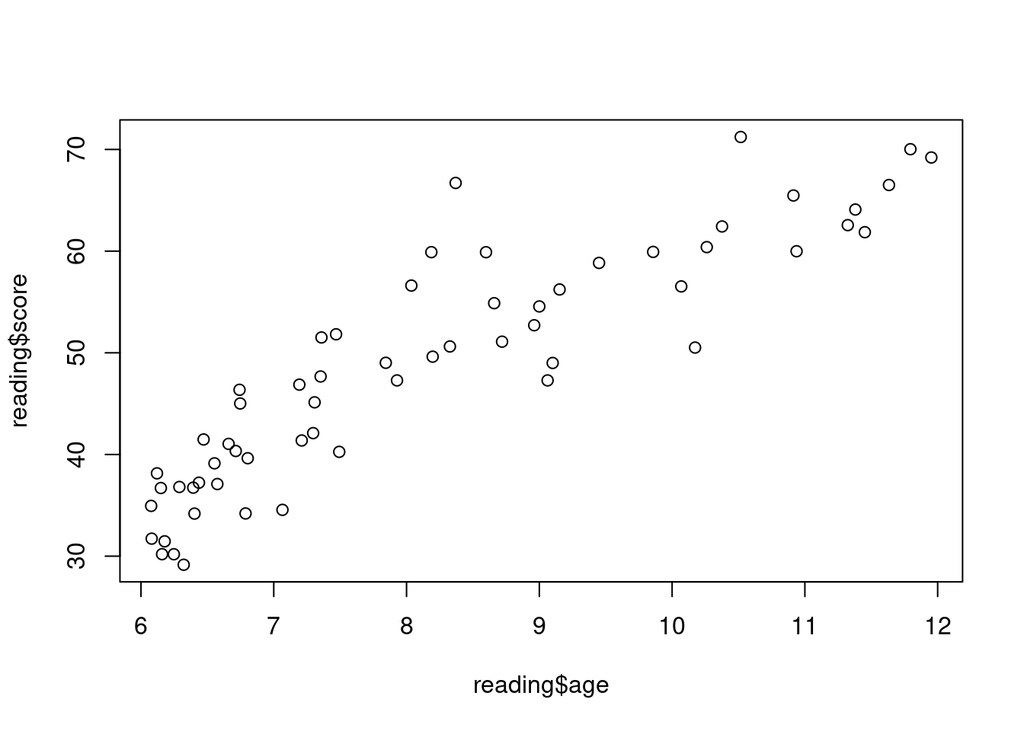

```r
plot(reading$age, reading$score)
```

The first input of the function `plot` corresponds to the “x-axis” and the second input corresponds to the “y-axis”. We can modify the labels on and x- and y-axis as follows:

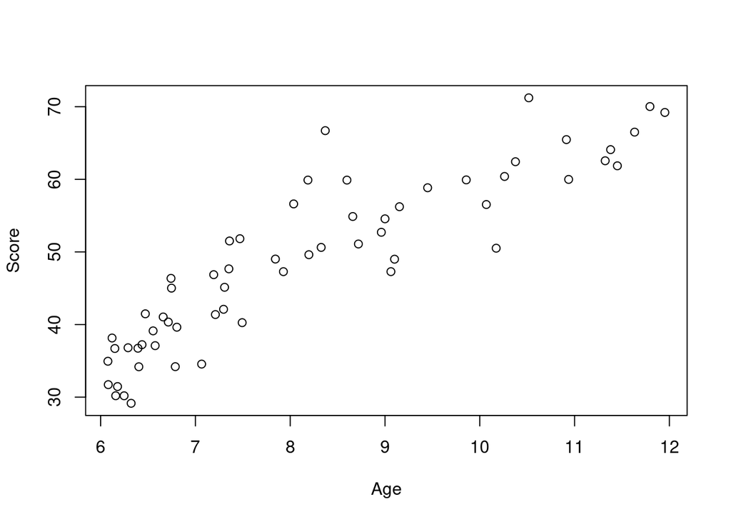

```r
plot(reading$age, reading$score, xlab = "Age", ylab = "Score")
```

Next, we will highlight the different groups using two colors. For this purpose, we need to create one variable `group_col` indicating in which groups the points on the graph belong to:

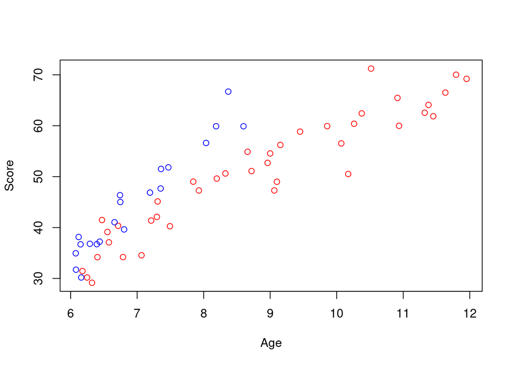

```r
# Define the colors we want to use
colors = c("blue", "red")
group_col = 1 + as.numeric(reading$group == "Control")
plot(reading$age, reading$score, xlab = "Age", ylab = "Score",
     col = colors[group_col])
```

Finally, we can add a legend as follows:

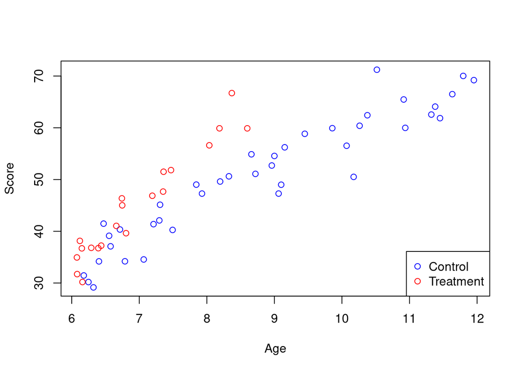

```r
# Define the colors we want to use
colors = c("blue", "red")
group_col = 1 + as.numeric(reading$group == "Treatment")
plot(reading$age, reading$score, xlab = "Age", ylab = "Score",
     col = colors[group_col])
legend("bottomright", c("Control", "Treatment"), pch = 1, col = colors)
```

We can now compute predictions from our model. It can be observed that the age of the children ranges from 6 to 12 so our first step is to construct a sequence of numbers from 6 to 12 as follows:

```r
age_to_predict = 6:12
age_to_predict
```

```
## [1]  6  7  8  9 10 11 12
```

```
[1]  6  7  8  9 10 11 12
```

Then, using the output of the model we have that the predictions for the group “Control” are:

$$\color{#e64173}{\text{Predicted Score}_i} = -7.8639 + 6.6457 \color{#20B2AA}{\text{Age}_i}.$$
This can be done as follows:

```r
prediction_control = -7.8639 + 6.6457*age_to_predict
prediction_control
```

```
## [1] 32.0103 38.6560 45.3017 51.9474 58.5931 65.2388 71.8845
```

```
[1] 32.0103 38.6560 45.3017 51.9474 58.5931 65.2388 71.8845
```

Alternatively, we can construct an object with the data we would like to predict as follows:

```r
data_to_predict = data.frame(age = age_to_predict,
                            group = rep("Control", length(age_to_predict)))
data_to_predict
```

```
##   age   group
## 1   6 Control
## 2   7 Control
## 3   8 Control
## 4   9 Control
## 5  10 Control
## 6  11 Control
## 7  12 Control
```

```
  age   group
1   6 Control
2   7 Control
3   8 Control
4   9 Control
5  10 Control
6  11 Control
7  12 Control
```

Then, we can use the function `predict` as follows:

```r
prediction_control = predict(mod1, data_to_predict)
prediction_control
```

```
##        1        2        3        4        5        6        7
## 32.01012 38.65579 45.30145 51.94712 58.59278 65.23845 71.88411
```

```
       1        2        3        4        5        6        7
32.01012 38.65579 45.30145 51.94712 58.59278 65.23845 71.88411
```

This approach provides the same results but is more reliable. Similarly, we can compute the predictions for the other groups as follows:

```r
data_to_predict = data.frame(age = age_to_predict,
                            group = rep("Treatment", length(age_to_predict)))
prediction_treatment = predict(mod1, data_to_predict)
prediction_treatment
```

```
##        1        2        3        4        5        6        7
## 38.38719 45.03286 51.67852 58.32419 64.96985 71.61552 78.26118
```

```
       1        2        3        4        5        6        7
38.38719 45.03286 51.67852 58.32419 64.96985 71.61552 78.26118
```

Now, we can add our predictions to the graph by simply using the function `lines` as follows:

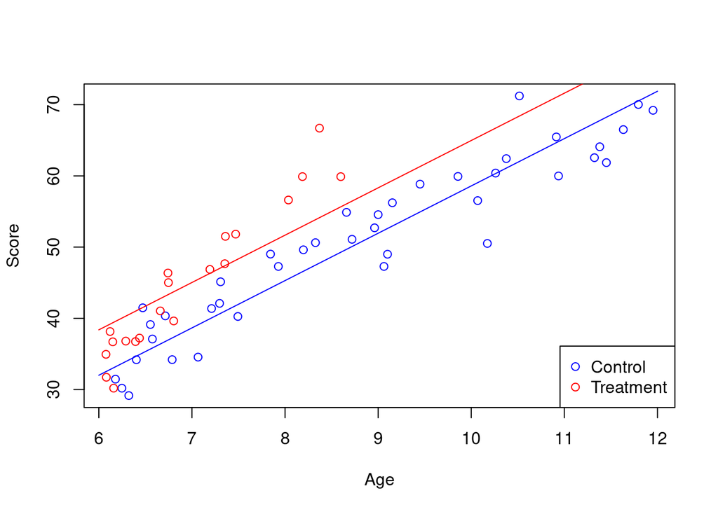

```r
# Define the colors we want to use
colors = c("blue", "red")
group_col = 1 + as.numeric(reading$group == "Treatment")
plot(reading$age, reading$score, xlab = "Age", ylab = "Score",
     col = colors[group_col])

# Add predictions
lines(age_to_predict, prediction_control, col = colors[1])
lines(age_to_predict, prediction_treatment, col = colors[2])

# Legend
legend("bottomright", c("Control", "Treatment"), pch = 1, col = colors)
```

As discussed in the lecture slides, the adequacy between our predictions and the data is not ideal. To highlight the limitations of this model we will consider model diagnostic graphs in the next section.

# 4. Analysis of Reading dataset - Model diagnostic

In this section, we consider the construction of model diagnostic graphs discussed in the lecture slides. The first graph compares the fitted values (i.e the predictions) with the residuals of the model. The fitted values and the residuals of the model can be computed as follows:

```r
# Fitted values
fitted_values = predict(mod1)

# Residuals
residuals = resid(mod1)
```

Then, we can construct the graph using the function `plot` as follows:

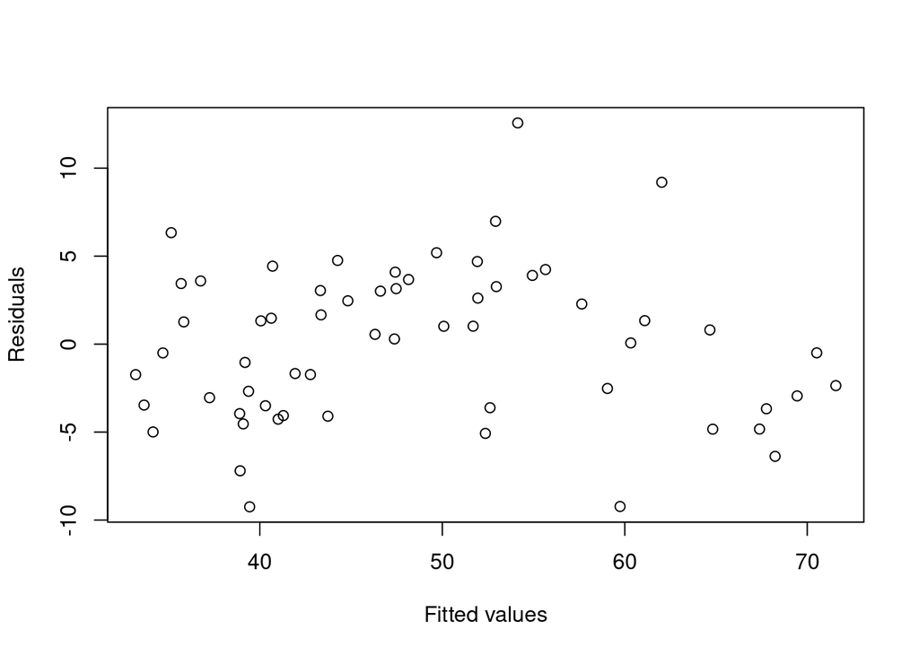

```r
plot(fitted_values, residuals, xlab = "Fitted values", ylab = "Residuals")
```

Similarly to what we did before, we can also add different colors to compare the groups:

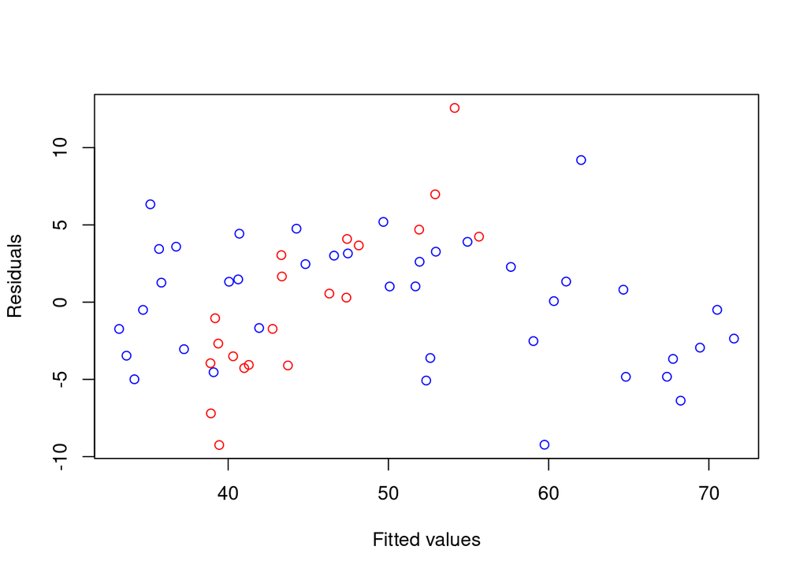

```r
colors = c("blue", "red")
group_col = 1 + as.numeric(reading$group == "Treatment")
plot(fitted_values, residuals, xlab = "Fitted values",
     ylab = "Residuals", col = colors[group_col])
```

This graph clearly illustrates the limitation of our model. We can also construct a normal Q-Q plot to assess if the empirical distribution of the residuals is close to a normal distribution using the functions `qqnorm` and `qqline`:

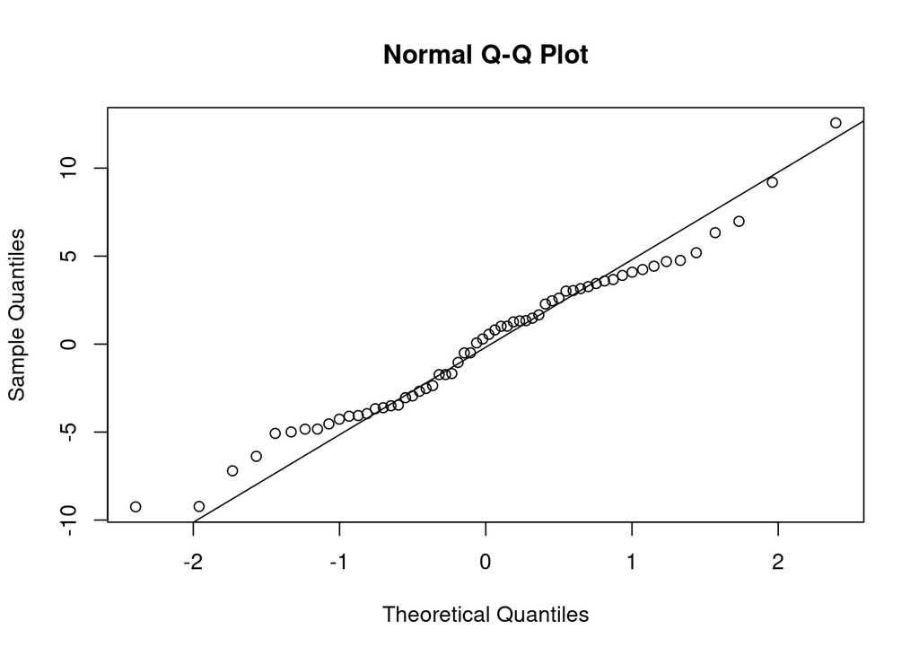

```r
qqnorm(residuals)
qqline(residuals)
```

# 5. Analysis of Reading dataset - Improving our model

We have seen in the previous section that our model didn’t appear suitable for our data. In the lecture slides, we propose the following alternative model:

$$\color{#e64173}{\text{Score}_i} = \beta_0 + \beta_1 \color{#6A5ACD}{\text{Group}_i} + \beta_2 \color{#20B2AA}{\text{Age}_i} + \beta_3 \color{#6A5ACD}{\text{Group}_i}\color{#20B2AA}{\text{Age}_i} + \epsilon_i, \quad \epsilon_i \overset{iid}{\sim} \mathcal{N}(0, \sigma^2).$$
The parameters of this second model can be estimated as follows:

```r
mod2 = lm(score ~ group*age, data = reading)
summary(mod2)
```

```
##
## Call:
## lm(formula = score ~ group * age, data = reading)
##
## Residuals:
##     Min      1Q  Median      3Q     Max
## -8.5033 -2.3708  0.4076  2.5478 10.1024
##
## Coefficients:
##                    Estimate Std. Error t value Pr(>|t|)
## (Intercept)         -3.2489     2.7903  -1.164    0.249
## groupTreatment     -36.0307     7.5392  -4.779 1.31e-05 ***
## age                  6.1207     0.3108  19.693  < 2e-16 ***
## groupTreatment:age   5.9539     1.0468   5.688 4.86e-07 ***
## ---
## Signif. codes:  0 '***' 0.001 '**' 0.01 '*' 0.05 '.' 0.1 ' ' 1
##
## Residual standard error: 3.572 on 56 degrees of freedom
## Multiple R-squared:  0.9104, Adjusted R-squared:  0.9056
## F-statistic: 189.6 on 3 and 56 DF,  p-value: < 2.2e-16
```

```
Call:
lm(formula = score ~ group * age, data = reading)

Residuals:
    Min      1Q  Median      3Q     Max
-8.5033 -2.3708  0.4076  2.5478 10.1024

Coefficients:
                   Estimate Std. Error t value Pr(>|t|)
(Intercept)         -3.2489     2.7903  -1.164    0.249
groupTreatment     -36.0307     7.5392  -4.779 1.31e-05 ***
age                  6.1207     0.3108  19.693  < 2e-16 ***
groupTreatment:age   5.9539     1.0468   5.688 4.86e-07 ***
---
Signif. codes:  0 ‘***’ 0.001 ‘**’ 0.01 ‘*’ 0.05 ‘.’ 0.1 ‘ ’ 1

Residual standard error: 3.572 on 56 degrees of freedom
Multiple R-squared:  0.9104,    Adjusted R-squared:  0.9056
F-statistic: 189.6 on 3 and 56 DF,  p-value: < 2.2e-16
```

To assess its adequacy, we compare the predictions and data as follows:

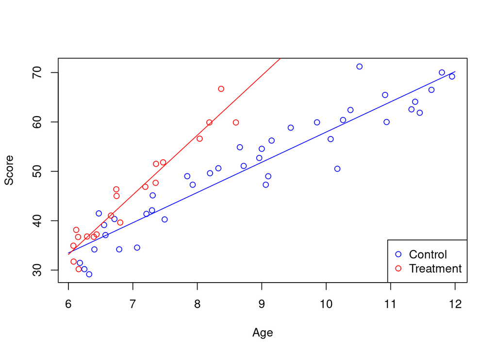

```r
# Compute predictions
age_to_predict = 6:12
data_control   = data.frame(age = age_to_predict,
                          group = rep("Control", length(age_to_predict)))
data_treatment = data.frame(age = age_to_predict,
                          group = rep("Treatment", length(age_to_predict)))
prediction_control = predict(mod2, data_control)
prediction_treatment = predict(mod2, data_treatment)

# Define the colors we want to use
colors = c("blue", "red")
group_col = 1 + as.numeric(reading$group == "Treatment")
plot(reading$age, reading$score, xlab = "Age", ylab = "Score",
     col = colors[group_col])

# Add predictions
lines(age_to_predict, prediction_control, col = colors[1])
lines(age_to_predict, prediction_treatment, col = colors[2])

# Legend
legend("bottomright", c("Control", "Treatment"), pch = 1, col = colors)
```

Based on this graph, our second model appears to be more adequate than our first model. We can also compare the AIC of these two models as follows:

```r
AIC(mod1)
```

```
## [1] 354.2688
```

```r
AIC(mod2)
```

```
## [1] 328.9095
```

```
[1] 354.2688
[1] 328.9095
```

This approach also suggests that the second model is more adequate. Similarly to what we did previously, we can construct the model diagnostic graphs as follows:

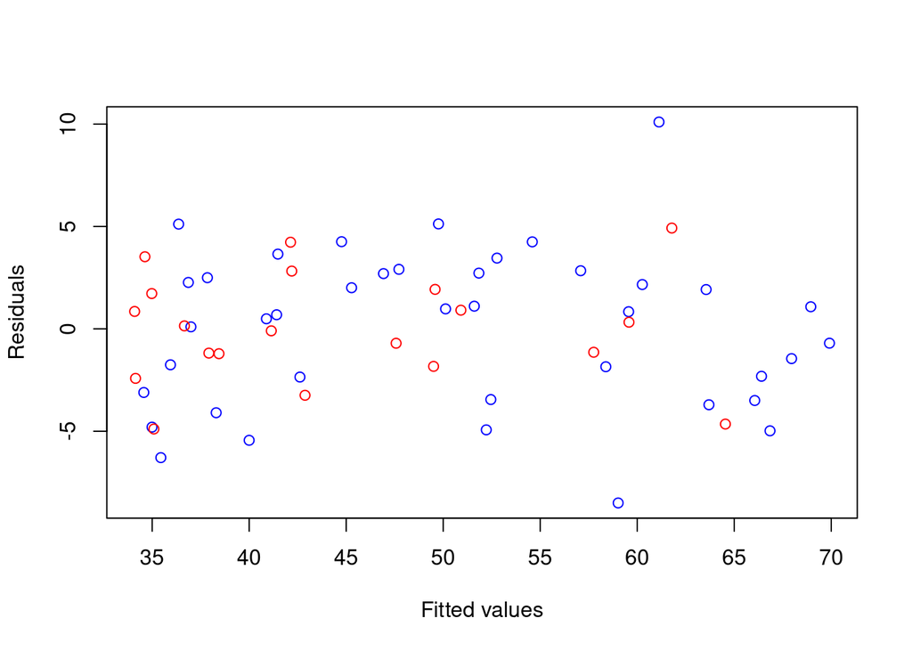

```r
colors = c("blue", "red")
group_col = 1 + as.numeric(reading$group == "Treatment")
plot(fitted(mod2), resid(mod2), xlab = "Fitted values",
     ylab = "Residuals", col = colors[group_col])
```

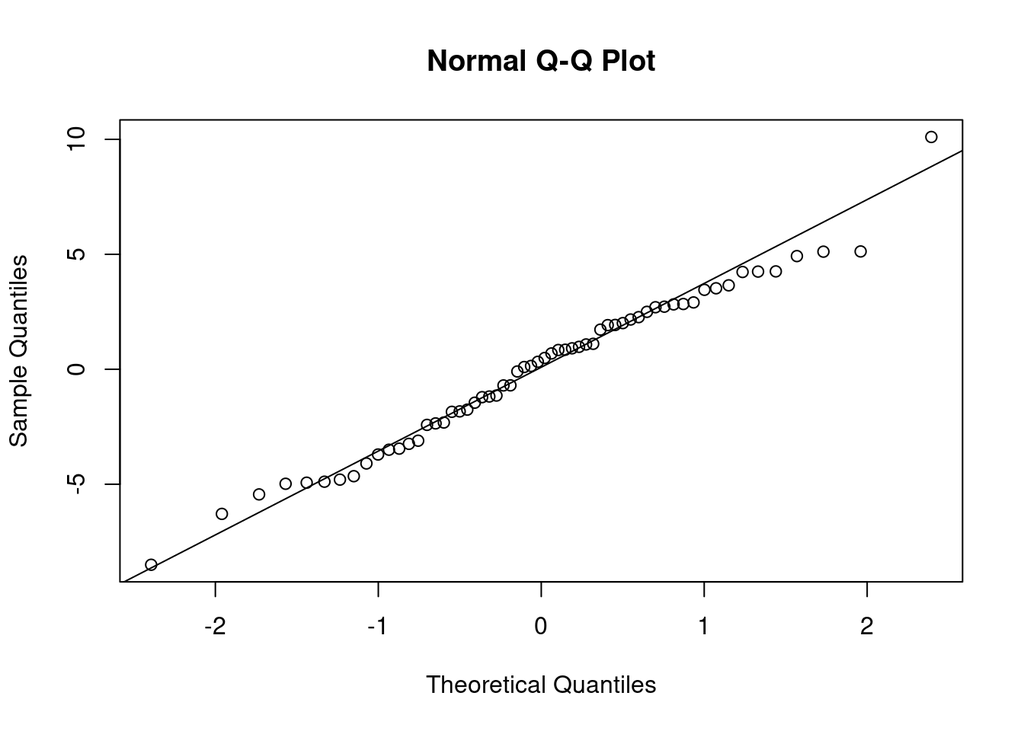

```r
qqnorm(resid(mod2))
qqline(resid(mod2))
```

Both graphs suggest that the model is a reasonable approximation for the data we considering. However, in the lecture slides we consider a third model which is given by:

$$\color{#e64173}{\text{Score}_i} = \beta_0 + \beta_1 \color{#20B2AA}{(\text{Age}_i - 6)} + \beta_2 \color{#6A5ACD}{\text{Group}_i}\color{#20B2AA}{(\text{Age}_i - 6)} + \epsilon_i, \quad \epsilon_i \overset{iid}{\sim} \mathcal{N}(0, \sigma^2).$$
To consider this model we first need to construct the variable “Age - 6”, which can be done as follows:

```r
age_minus_6 = reading$age - 6
```

Then we can “add” this variable to our data:

```r
reading$age_minus_6 = age_minus_6
```

Then, the parameters of this third model can be estimated as follows:

```r
mod3 = lm(score ~ age_minus_6 + group:age_minus_6, data = reading)
summary(mod3)
```

```
##
## Call:
## lm(formula = score ~ age_minus_6 + group:age_minus_6, data = reading)
##
## Residuals:
##     Min      1Q  Median      3Q     Max
## -8.5095 -2.4182  0.4826  2.6312 10.0853
##
## Coefficients:
##                            Estimate Std. Error t value Pr(>|t|)
## (Intercept)                 33.3504     0.7904  42.192  < 2e-16 ***
## age_minus_6                  6.1522     0.2604  23.625  < 2e-16 ***
## age_minus_6:groupTreatment   5.8103     0.7157   8.119 4.37e-11 ***
## ---
## Signif. codes:  0 '***' 0.001 '**' 0.01 '*' 0.05 '.' 0.1 ' ' 1
##
## Residual standard error: 3.542 on 57 degrees of freedom
## Multiple R-squared:  0.9103, Adjusted R-squared:  0.9072
## F-statistic: 289.2 on 2 and 57 DF,  p-value: < 2.2e-16
```

```
Call:
lm(formula = score ~ age_minus_6 + group:age_minus_6, data = reading)

Residuals:
    Min      1Q  Median      3Q     Max
-8.5095 -2.4182  0.4826  2.6312 10.0853

Coefficients:
                           Estimate Std. Error t value Pr(>|t|)
(Intercept)                 33.3504     0.7904  42.192  < 2e-16 ***
age_minus_6                  6.1522     0.2604  23.625  < 2e-16 ***
age_minus_6:groupTreatment   5.8103     0.7157   8.119 4.37e-11 ***
---
Signif. codes:  0 ‘***’ 0.001 ‘**’ 0.01 ‘*’ 0.05 ‘.’ 0.1 ‘ ’ 1

Residual standard error: 3.542 on 57 degrees of freedom
Multiple R-squared:  0.9103,    Adjusted R-squared:  0.9072
F-statistic: 289.2 on 2 and 57 DF,  p-value: < 2.2e-16
```

To assess the model adequacy, we compare the predictions and data as follows (note that this model is based on `age_minus_6` and not `age`):

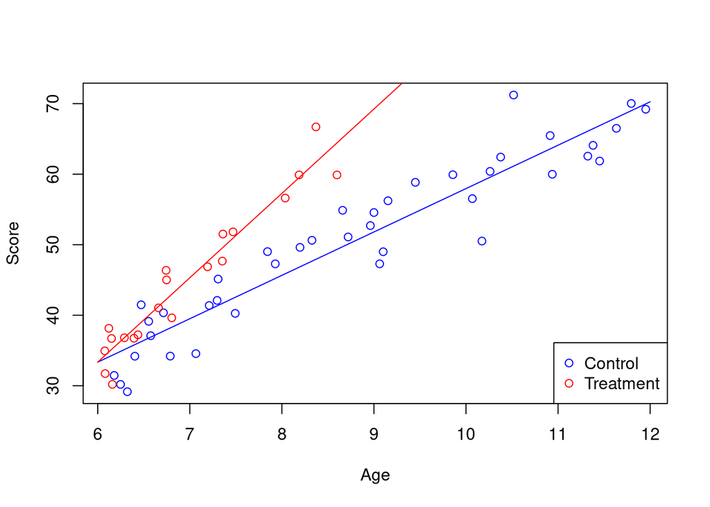

```r
# Compute predictions
age_to_predict = 0:6
data_control   = data.frame(age_minus_6 = age_to_predict,
                          group = rep("Control", length(age_to_predict)))
data_treatment = data.frame(age_minus_6 = age_to_predict,
                          group = rep("Treatment", length(age_to_predict)))
prediction_control = predict(mod3, data_control)
prediction_treatment = predict(mod3, data_treatment)

# Define the colors we want to use
colors = c("blue", "red")
group_col = 1 + as.numeric(reading$group == "Treatment")
plot(reading$age, reading$score, xlab = "Age", ylab = "Score",
     col = colors[group_col])

# Add predictions
lines(age_to_predict + 6, prediction_control, col = colors[1])
lines(age_to_predict + 6, prediction_treatment, col = colors[2])

# Legend
legend("bottomright", c("Control", "Treatment"), pch = 1, col = colors)
```

```r
AIC(mod1)
```

```
## [1] 354.2688
```

```r
AIC(mod2)
```

```
## [1] 328.9095
```

```r
AIC(mod3)
```

```
## [1] 326.9479
```

```
[1] 354.2688
[1] 328.9095
[1] 326.9479
```

This approach suggests that the third model is the most adequate among all three models we have considered. Finally, we can construct the model diagnostic graphs as follows:

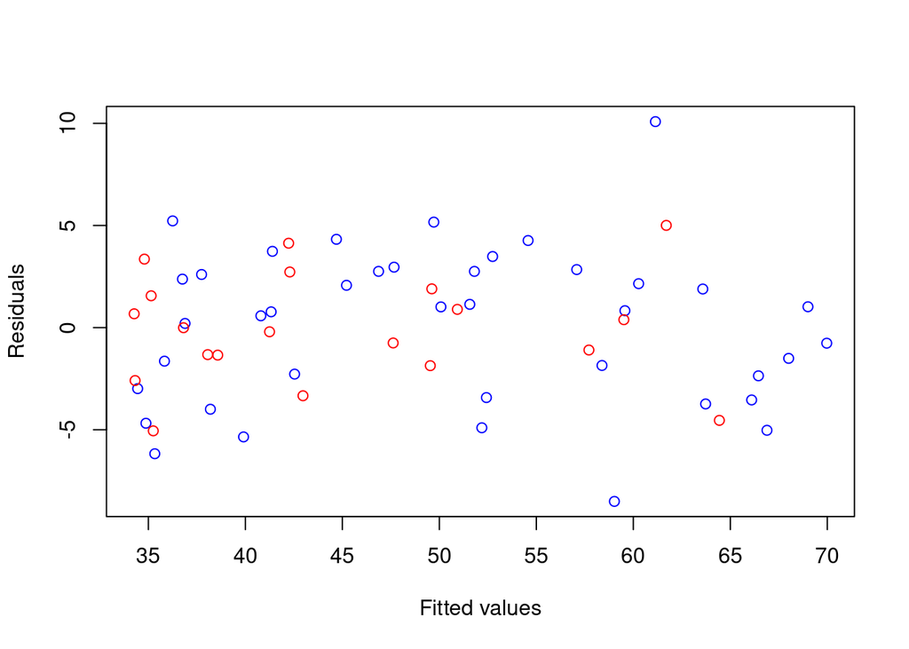

```r
colors = c("blue", "red")
group_col = 1 + as.numeric(reading$group == "Treatment")
plot(fitted(mod3), resid(mod3), xlab = "Fitted values",
     ylab = "Residuals", col = colors[group_col])
```

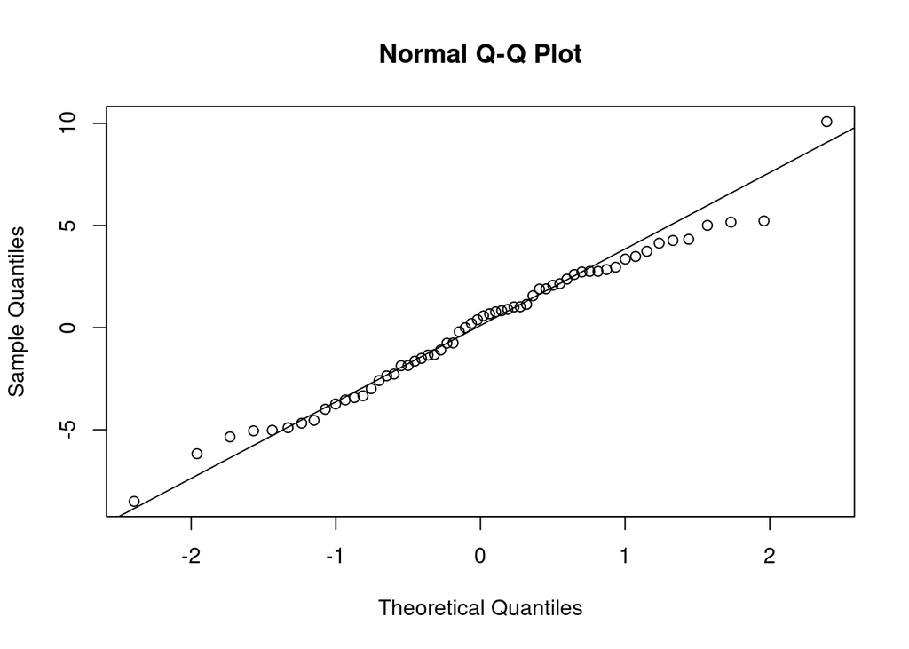

```r
qqnorm(resid(mod3))
qqline(resid(mod3))
```

Similarly to the diagnostic plot of the second model, both graphs suggest that the third model is a reasonable approximation for the data we are considering.

# 6. Analysis of Reading dataset - Confidence intervals for predictions

In the previous section, we saw that the third model appears to be the most adequate among all three models we have considered. The prediction for this model can be expressed as follows:

$$\color{#e64173}{\text{Prediction Score}_i} = 33.3504 + 6.1522 \color{#20B2AA}{(\text{Age}_i - 6)} + 5.8103 \color{#6A5ACD}{\text{Group}_i}\color{#20B2AA}{(\text{Age}_i - 6)},$$
which corresponds to the expected (or average) score for a child of a certain age in a certain group. But how certain are we about this expected score? To answer this question, we can compute confidence intervals (typically at the 95% confidence level) for our predicted scores. This can be done very similarly to what we did before using the function `predict`. First, we recall how the third model is estimated:

```r
library(idar)
data(reading)
reading$age_minus_6 = age_minus_6
mod3 = lm(score ~ age_minus_6 + group:age_minus_6, data = reading)
```

Suppose we wish to construct the predictions for children of age 6 to 12 in the control group. In the previous slides we saw that this could be done as follows:

```r
# Compute predictions
age_to_predict = 0:6
data_control   = data.frame(age_minus_6 = age_to_predict,
                            group = rep("Control", length(age_to_predict)))
prediction_control = predict(mod3, data_control)
prediction_control
```

```
##        1        2        3        4        5        6        7
## 33.35044 39.50267 45.65489 51.80712 57.95934 64.11157 70.26379
```

```
       1        2        3        4        5        6        7
33.35044 39.50267 45.65489 51.80712 57.95934 64.11157 70.26379
```

To obtain confidence intervals for these predictions, we need to add `interval = "confidence"` in the function `predict` as follows:

```r
prediction_control = predict(mod3, data_control, interval = "confidence")
prediction_control
```

```
##        fit      lwr      upr
## 1 33.35044 31.76762 34.93327
## 2 39.50267 38.27118 40.73416
## 3 45.65489 44.61969 46.69010
## 4 51.80712 50.72519 52.88905
## 5 57.95934 56.61274 59.30594
## 6 64.11157 62.37954 65.84360
## 7 70.26379 68.08885 72.43874
```

```
       fit      lwr      upr
1 33.35044 31.76762 34.93327
2 39.50267 38.27118 40.73416
3 45.65489 44.61969 46.69010
4 51.80712 50.72519 52.88905
5 57.95934 56.61274 59.30594
6 64.11157 62.37954 65.84360
7 70.26379 68.08885 72.43874
```

In this output, the first column `fit` corresponds to our prediction while the second and third columns correspond to the lower and upper values of the confidence intervals (at the 95% confidence level) for these predictions. For example, for a child of age 7 (i.e. `age_minus_6` is 1 so we should check the second row of the results), our (mean) prediction is 39.50267 and a 95% confidence interval for this value is (38.27118 40.73416). Similarly, for the treatment group we can compute predictions and confidence intervals as follows:

```r
# Compute predictions
age_to_predict = 0:6
data_treatment = data.frame(age_minus_6 = age_to_predict,
                            group = rep("Treatment", length(age_to_predict)))
prediction_treatment = predict(mod3, data_treatment, interval = "confidence")
prediction_treatment
```

```
##         fit      lwr       upr
## 1  33.35044 31.76762  34.93327
## 2  45.31299 43.90573  46.72025
## 3  57.27554 54.71227  59.83881
## 4  69.23808 65.20382  73.27234
## 5  81.20063 75.62434  86.77693
## 6  93.16318 86.01966 100.30669
## 7 105.12573 96.40337 113.84808
```

```
        fit      lwr       upr
1  33.35044 31.76762  34.93327
2  45.31299 43.90573  46.72025
3  57.27554 54.71227  59.83881
4  69.23808 65.20382  73.27234
5  81.20063 75.62434  86.77693
6  93.16318 86.01966 100.30669
7 105.12573 96.40337 113.84808
```

To better understand what these confidence intervals represent, we can add them to the graph in which we compare the predictions and the original data. We recall that this graph can be construct as follows:

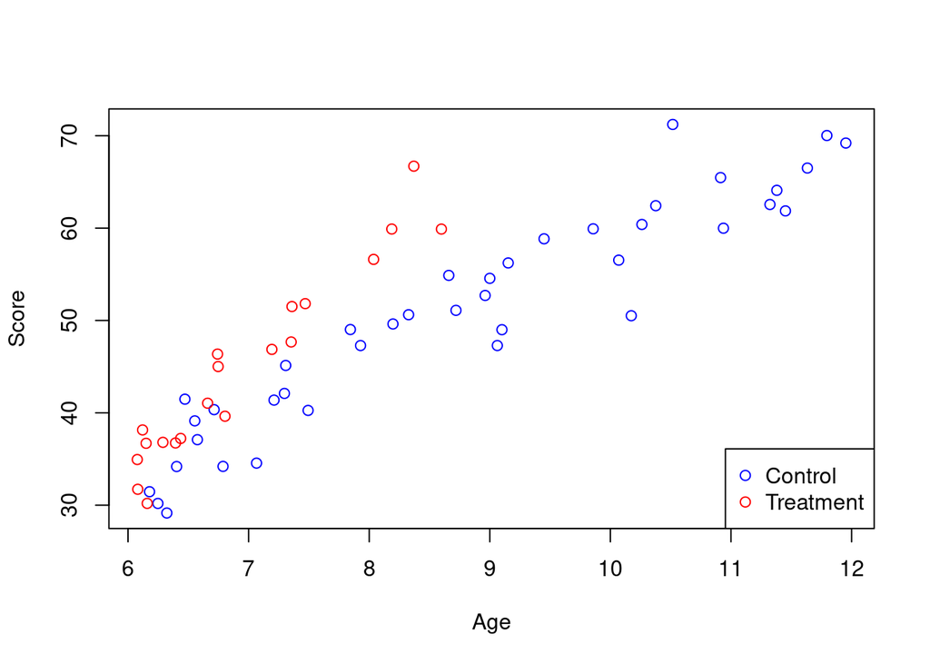

```r
# Define the colors we want to use
colors = c("blue", "red")
group_col = 1 + as.numeric(reading$group == "Treatment")
plot(reading$age, reading$score, xlab = "Age", ylab = "Score",
     col = colors[group_col])

# Legend
legend("bottomright", c("Control", "Treatment"), pch = 1, col = colors)
```

We can add our predictions for the control group by writing:

```r
lines(age_to_predict + 6, prediction_control[,1], col = colors[1])
```

We can also use the following to add the lower and upper values of the confidence intervals (note that the option `lty = 2` is used to obtain a dashed line):

```r
lines(age_to_predict + 6, prediction_control[,2], col = colors[1], lty = 2)
lines(age_to_predict + 6, prediction_control[,3], col = colors[1], lty = 2)
```

Therefore, the code for the graph becomes:

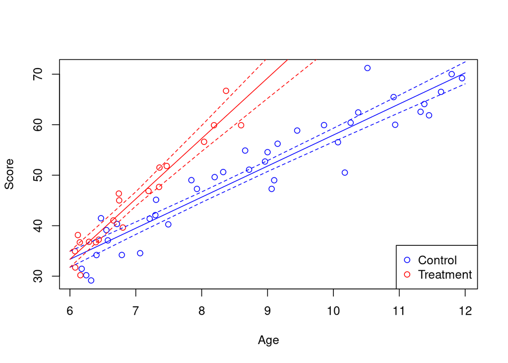

```r
# Define the colors we want to use
colors = c("blue", "red")
group_col = 1 + as.numeric(reading$group == "Treatment")
plot(reading$age, reading$score, xlab = "Age", ylab = "Score",
     col = colors[group_col])

# Predictions
lines(age_to_predict + 6, prediction_control[,1], col = colors[1])
lines(age_to_predict + 6, prediction_control[,2], col = colors[1], lty = 2)
lines(age_to_predict + 6, prediction_control[,3], col = colors[1], lty = 2)

lines(age_to_predict + 6, prediction_treatment[,1], col = colors[2])
lines(age_to_predict + 6, prediction_treatment[,2], col = colors[2], lty = 2)
lines(age_to_predict + 6, prediction_treatment[,3], col = colors[2], lty = 2)

# Legend
legend("bottomright", c("Control", "Treatment"), pch = 1, col = colors)
```

In some situations, it is also of interest to compute a prediction interval, which corresponds to a confidence interval for the score of a child of a certain age and group. This is different from a confidence interval for the mean. Indeed, in the previous graph we can see that many points are outside of the confidence region (which makes sense since the intervals are confidence intervals for the means). We can construct prediction intervals very similarly to what we did before by using `interval = "prediction"` instead of `interval = "confidence"` in the function `predict`. For example, to construct the prediction intervals for children of age 6 to 12 we can write:

```r
prediction_control = predict(mod3, data_control, interval = "prediction")
prediction_treatment = predict(mod3, data_treatment, interval = "prediction")
prediction_control
```

```
##        fit      lwr      upr
## 1 33.35044 26.08382 40.61706
## 2 39.50267 32.30440 46.70093
## 3 45.65489 38.48760 52.82218
## 4 51.80712 44.63293 58.98131
## 5 57.95934 50.74050 65.17819
## 6 64.11157 56.81100 71.41214
## 7 70.26379 62.84566 77.68193
```

```
       fit      lwr      upr
1 33.35044 26.08382 40.61706
2 39.50267 32.30440 46.70093
3 45.65489 38.48760 52.82218
4 51.80712 44.63293 58.98131
5 57.95934 50.74050 65.17819
6 64.11157 56.81100 71.41214
7 70.26379 62.84566 77.68193
```

In this output, we can see that our prediction intervals are much wider than the previous confidence intervals. For example, for a child of age 7 our predicted score is 39.50267 but the corresponding 95% prediction interval is (32.30440 46.70093). This means that with a probability of 95%, we expect the score of a child of age 7 in the control group to be somewhere between 32.30440 and 46.70093. Naturally, we can produce a graph similarly to the one we considered previously as follows:

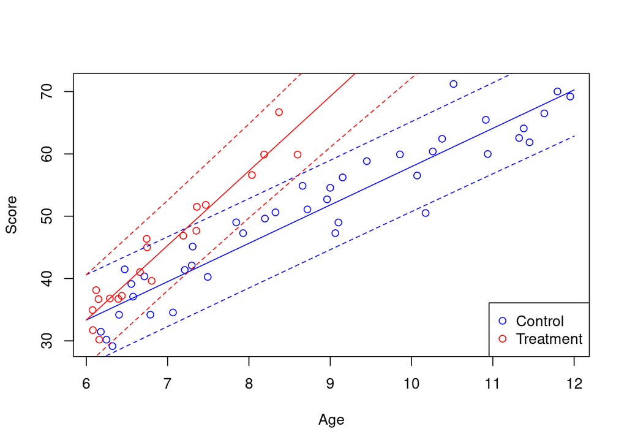

```r
# Define the colors we want to use
colors = c("blue", "red")
group_col = 1 + as.numeric(reading$group == "Treatment")
plot(reading$age, reading$score, xlab = "Age", ylab = "Score",
     col = colors[group_col])

# Predictions
lines(age_to_predict + 6, prediction_control[,1], col = colors[1])
lines(age_to_predict + 6, prediction_control[,2], col = colors[1], lty = 2)
lines(age_to_predict + 6, prediction_control[,3], col = colors[1], lty = 2)

lines(age_to_predict + 6, prediction_treatment[,1], col = colors[2])
lines(age_to_predict + 6, prediction_treatment[,2], col = colors[2], lty = 2)
lines(age_to_predict + 6, prediction_treatment[,3], col = colors[2], lty = 2)

# Legend
legend("bottomright", c("Control", "Treatment"), pch = 1, col = colors)
```

# Exercise: Pharmacokinetics of Indomethacin

In this exercise we will consider a dataset on the pharmacokinetics of indometacin which is an anti-inflammatory drug commonly used as a prescription medication to reduce fever, pain, stiffness, and swelling from inflammation. This dataset can be downloaded as follows:

```r
data(Indometh)
```

We can have a first look at the data by using

```r
head(Indometh)
```

```
##   Subject time conc
## 1       1 0.25 1.50
## 2       1 0.50 0.94
## 3       1 0.75 0.78
## 4       1 1.00 0.48
## 5       1 1.25 0.37
## 6       1 2.00 0.19
```

Our objective is the model the concentration (i.e. plasma concentrations of indometacin measured in mcg/ml) as a function of the times at which blood samples were drawn (in hr). The first variable corresponds to `Indometh$conc` and the second to `Indometh$time`.

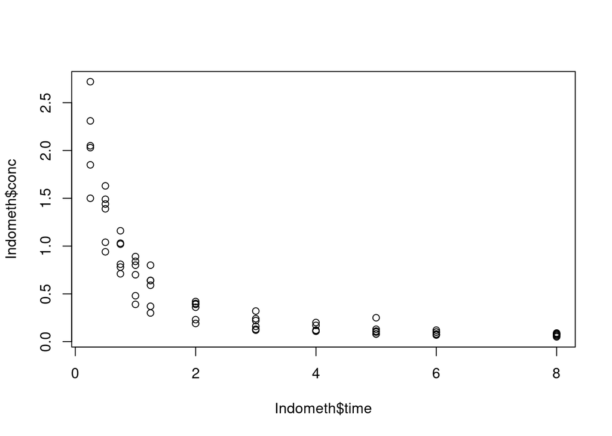

```r
plot(Indometh$time, Indometh$conc)
```

Consider the inbuilt R dataset `Indometh`, which contains data on the pharmacokinetics of indometacin. - Plot `Indometh$time` versus `Indometh$conc` (concentration). What is the nature of the relationship between `time` and `conc`?

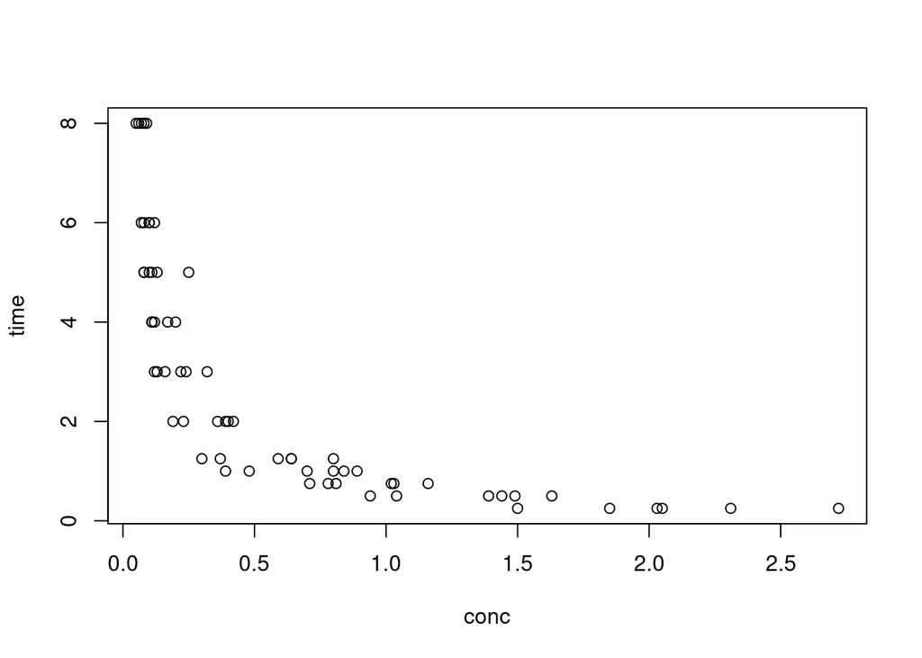

```r
plot(time~conc,data=Indometh)
```

```r
# There is a non-linear negative relationship between time and conc
```

- Apply monotonic transformations to the data so that a simple linear regression model can be used to model the relationship (ensure both linearity and stabilised variance, within reason). Create a plot of the transformed data, to confirm that the relationship seems linear.

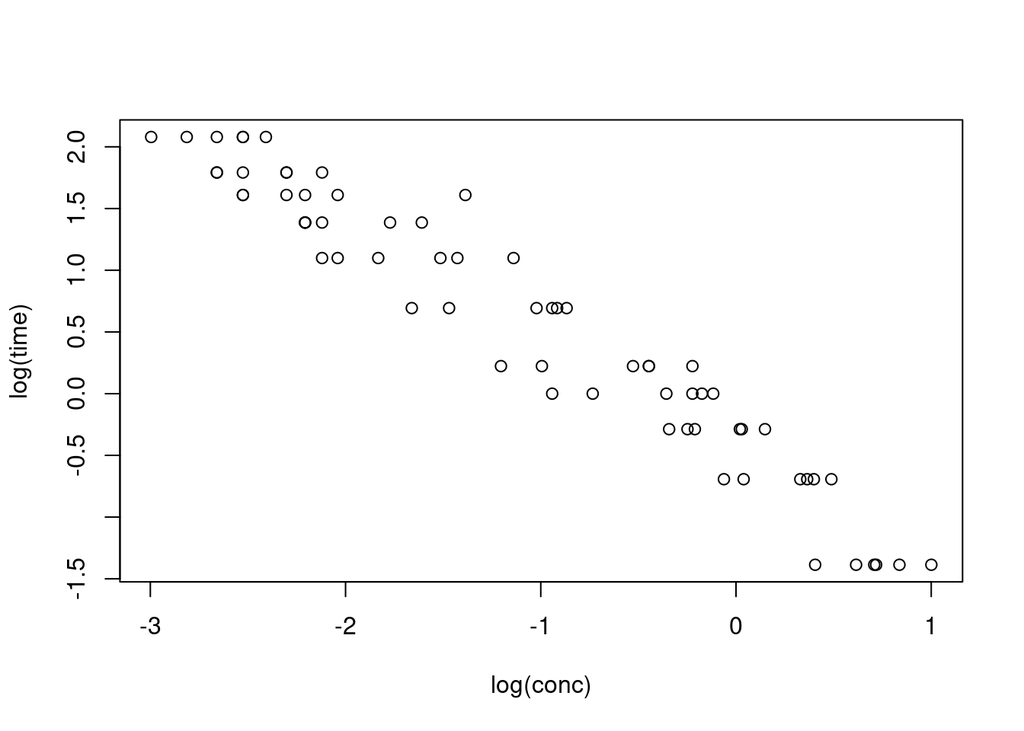

```r
plot(log(time)~log(conc),data=Indometh)
```

- After creating the linear model, inspect the diagnostic plots to ensure that the assumptions are not violated (too much). Are there any outliers with large influence? What are the parameter estimates? Are both terms significant?

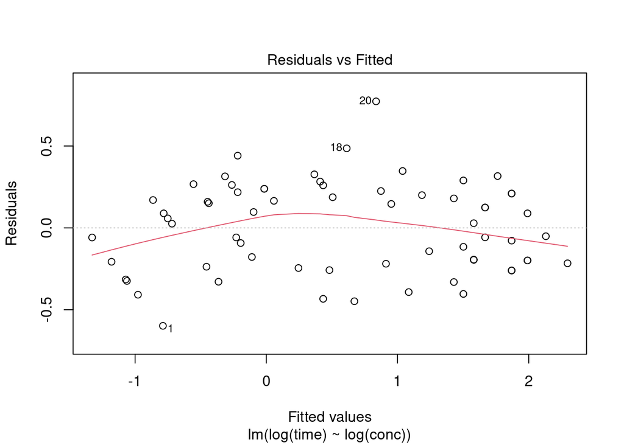

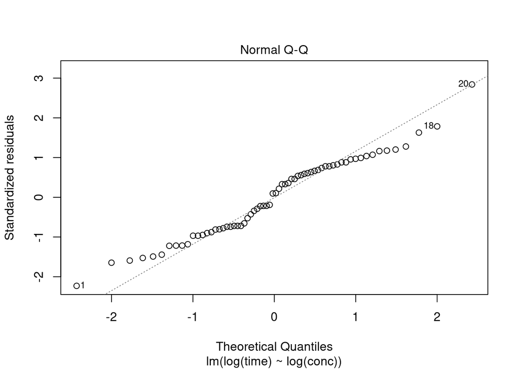

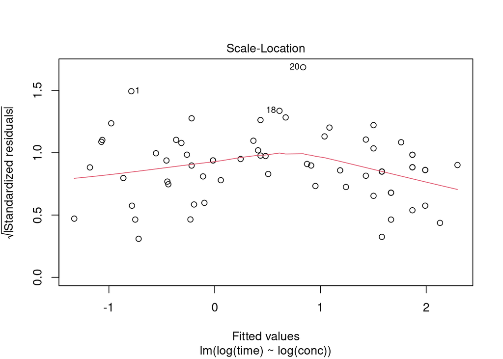

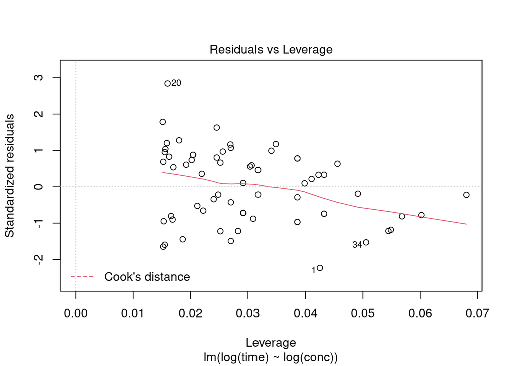

```r
m8 = lm(log(time)~log(conc),data=Indometh)
plot(m8)
```

```r
# The diagnostic plots indicate that the residuals aren't perfectly Normally distributed, but the modelling assumptions aren't violated so much as to inhibit construction of a model.
summary(m8)
```

```
##
## Call:
## lm(formula = log(time) ~ log(conc), data = Indometh)
##
## Residuals:
##      Min       1Q   Median       3Q      Max
## -0.59838 -0.21398  0.02711  0.20979  0.77285
##
## Coefficients:
##             Estimate Std. Error t value Pr(>|t|)
## (Intercept)  -0.4203     0.0474  -8.867 9.67e-13 ***
## log(conc)    -0.9066     0.0298 -30.429  < 2e-16 ***
## ---
## Signif. codes:  0 '***' 0.001 '**' 0.01 '*' 0.05 '.' 0.1 ' ' 1
##
## Residual standard error: 0.2743 on 64 degrees of freedom
## Multiple R-squared:  0.9353, Adjusted R-squared:  0.9343
## F-statistic: 925.9 on 1 and 64 DF,  p-value: < 2.2e-16
```

```r
# Intercept = -0.4203
# Coefficient of log(conc) = -0.9066
# Both terms are significantly different from zero.
```

- Add a line to the plot showing the linear relationship between the transformed data.

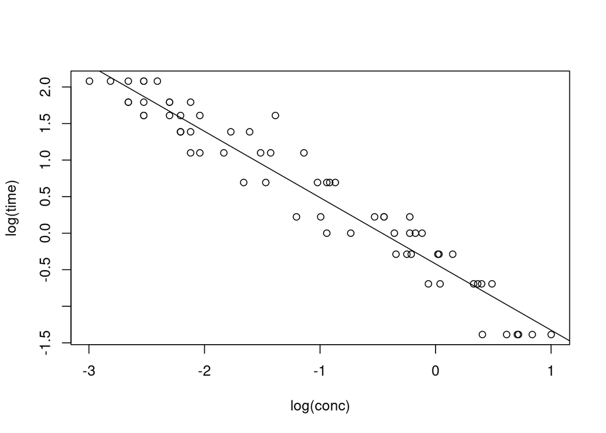

```r
plot(log(time)~log(conc),data=Indometh)
abline(m8)
```

- Now regenerate the original plot of `time` versus `conc` (i.e. the untransformed data). Using the `lines` function, add a curve to the plot corresponding to the fitted values of the model.

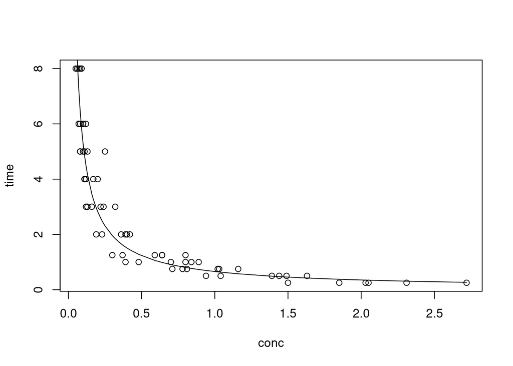

```r
plot(time~conc,data=Indometh)
idx <- order(Indometh$conc)
lines(exp(fitted(m8))[idx]~Indometh$conc[idx])
```

Plot Indometh$time versus Indometh$conc (concentration). What is the nature of the relationship between time and conc?

Consider the inbuilt R dataset Indometh, which contains data on the pharmacokinetics of indometacin.

```
Plot Indometh$time versus Indometh$conc (concentration). What is the nature of the relationship between time and conc?
Apply monotonic transformations to the data so that a simple linear regression model can be used to model the relationship (ensure both linearity and stabilised variance, within reason). Create a plot of the transformed data, to confirm that the relationship seems linear.
After creating the linear model, inspect the diagnostic plots to ensure that the assumptions are not violated (too much). Are there any outliers with large influence? What are the parameter estimates? Are both terms significant?
Add a line to the plot showing the linear relationship between the transformed data.
Now regenerate the original plot of time versus conc (i.e. the untransformed data). Using the lines function, add a curve to the plot corresponding to the fitted values of the model.
```

# Homework

We consider synthetic data based on Charepalli et al. (2018) where the impact on important biomarkers of different diets was studied. One of the experiment was conducted on pigs which were divided into two treatment groups, “C” and “NC”, corresponding to two dietary compositions. The first group “C” contains 20% of deep fried potatoes (i.e. chips) while this is not the case in the group “NC” which doesn’t contain any fried food. Caloric intake was measured weekly until the end of the study. The objective of our study is to evaluate the possible link existing between fried food consumption and its effects on inflammatory response. For this purpose, we will model the logarithm of the cortisol levels (in pg/mg) as a function of other variables (e.g. diet, caloric intake and so on). You can load the data as follows (make sure to update `idar`):

```r
library(idar)
data("cortisol")

# Log transform
cortisol$cortisol = log(cortisol$cortisol)
```

Two scientists working on this project have different (and contradicting) theories regarding the inflammatory response induced by fried food. Your objective is to model the data in a suitable way to assess the validity of their claims.

1. Scientist 1: There is no connection between fried food consumption and cortisol levels. However, caloric intake has a significant impact on cortisol levels.
2. Scientist 2: Fried food consumption as well as caloric intake have significant impact on cortisol levels. Higher amount of fried food consumption corresponds to higher cortisol levels.

Bonus: Explain how this problem relates to Simpson’s paradox, a phenomenon in Statistics in which a trend appears in several groups of data but disappears or reverses when the groups are combined.